# Cheat Sheet (Species Example)

2024-07-02

First load our data

```r
data(gala, package ="faraway")
```

Then we create our linear model of our data with Species as the result and Elevation as the input

```r
fit<- lm( Species ~ Elevation, data=gala)
```

We can calculate our estimated $\sigma^2$, equal to $Var(y_i)=Var(\epsilon_i)$, using the sum of residuals, or difference of each y and its estimated value, divided by the degrees of freedom, n, minus 2 This estimation is unbiased for $\sigma^2$. This calculation is essentially the same as doing $\frac{1}{N-2}\sum_{i=1}^n\epsilon_i^2$. $\hat{\sigma}$ = Residual Standard Error.

We can also get the $\sigma^2$ using summary(model)$sigma^2.

```r
sigma2.hat <- sum((fit$residuals^2))/fit$df.residual
sigma2.hat
```

```
## [1] 6187.638
```

```r
sigma.hat <- sqrt(sigma2.hat)
summary(fit)$sigma^2
```

```
## [1] 6187.638
```

We can estimate our $\beta_1$ and $\beta_0$ values using equations derived by setting derivatives of the SSR, sum of squared residuals, to zero with respect to both $\beta_1$ and $\beta_0$.

$\hat{\beta_1} = \frac{\sum_{i=1}^n(x_i-\bar{x})(y_i-\bar{y})}{\sum_{i=1}^n(x_i-\bar{x})^2}$

$\hat{\beta_0} = \bar{y} - \hat{\beta_1}\bar{x}$

We can prove that each of these estimates are unbiased, $E[\beta_i] = \beta_i$

We can also get these estimates by simply using coef(fit) or fit$coefficients.

```r
x <- gala$Elevation
y <- gala$Species
n <- length(y)
beta1 <- sum((y-mean(y))*(x-mean(x)))/sum((x-mean(x))^2)
beta1
```

```
## [1] 0.2007922
```

```r
beta0 <- mean(y)-beta1*mean(x)
beta0
```

```
## [1] 11.33511
```

```r
fit$coefficients
```

```
## (Intercept)   Elevation
##  11.3351132   0.2007922
```

```r
coef(fit)
```

```
## (Intercept)   Elevation
##  11.3351132   0.2007922
```

```r
SSR <- sum((fit$residuals)^2)
SSR
```

```
## [1] 173253.9
```

With these values we now can calculate our predictions for the y-values, $\hat{y}$, using $\hat{y_i}=\hat{\beta_0}+\hat{\beta_1}x_i$ for i=1,…,n. This can also be done using fitted(fit).

```r
y.hat <- beta0+beta1*x
y.hat
```

```
##  [1]  80.80921  33.22146  34.22542  20.57155  26.79611  35.22938  30.00879
##  [8]  45.06820  25.59136  33.82384  51.09197 311.31865  21.17393  56.91494
## [15]  26.59532 354.08739  80.20684  16.35492 167.35065 103.29794  30.20958
## [22]  85.02585 155.10232 193.25284 184.81957  63.34029 139.84212  40.85157
## [29]  48.68246  62.13554
```

```r
fitted(fit)
```

```
##       Baltra    Bartolome     Caldwell     Champion      Coamano Daphne.Major
##     80.80921     33.22146     34.22542     20.57155     26.79611     35.22938
## Daphne.Minor       Darwin         Eden      Enderby     Espanola   Fernandina
##     30.00879     45.06820     25.59136     33.82384     51.09197    311.31865
##     Gardner1     Gardner2     Genovesa      Isabela     Marchena       Onslow
##     21.17393     56.91494     26.59532    354.08739     80.20684     16.35492
##        Pinta       Pinzon   Las.Plazas       Rabida SanCristobal  SanSalvador
##    167.35065    103.29794     30.20958     85.02585    155.10232    193.25284
##    SantaCruz      SantaFe   SantaMaria      Seymour      Tortuga         Wolf
##    184.81957     63.34029    139.84212     40.85157     48.68246     62.13554
```

We can calculate the residuals, $y_i-\hat{y}$ for i=1,…,n, using fit$residuals or residuals(fit). This is essentially the error for each y value, or the difference between our prediction and the actual value.

```r
fit$residuals
```

```
##       Baltra    Bartolome     Caldwell     Champion      Coamano Daphne.Major
##   -22.809212    -2.221462   -31.225423     4.428446   -24.796112   -17.229384
## Daphne.Minor       Darwin         Eden      Enderby     Espanola   Fernandina
##    -6.008787   -35.068202   -17.591359   -31.823839    45.908033  -218.318650
##     Gardner1     Gardner2     Genovesa      Isabela     Marchena       Onslow
##    36.826069   -51.914941    13.404680    -7.087387   -29.206835   -14.354918
##        Pinta       Pinzon   Las.Plazas       Rabida SanCristobal  SanSalvador
##   -63.350647     4.702062   -18.209579   -15.025848   124.897677    43.747160
##    SantaCruz      SantaFe   SantaMaria      Seymour      Tortuga         Wolf
##   259.180432    -1.340291   145.157883     3.148434   -32.682461   -41.135538
```

```r
residuals(fit)
```

```
##       Baltra    Bartolome     Caldwell     Champion      Coamano Daphne.Major
##   -22.809212    -2.221462   -31.225423     4.428446   -24.796112   -17.229384
## Daphne.Minor       Darwin         Eden      Enderby     Espanola   Fernandina
##    -6.008787   -35.068202   -17.591359   -31.823839    45.908033  -218.318650
##     Gardner1     Gardner2     Genovesa      Isabela     Marchena       Onslow
##    36.826069   -51.914941    13.404680    -7.087387   -29.206835   -14.354918
##        Pinta       Pinzon   Las.Plazas       Rabida SanCristobal  SanSalvador
##   -63.350647     4.702062   -18.209579   -15.025848   124.897677    43.747160
##    SantaCruz      SantaFe   SantaMaria      Seymour      Tortuga         Wolf
##   259.180432    -1.340291   145.157883     3.148434   -32.682461   -41.135538
```

```r
y-y.hat
```

```
##  [1]  -22.809212   -2.221462  -31.225423    4.428446  -24.796112  -17.229384
##  [7]   -6.008787  -35.068202  -17.591359  -31.823839   45.908033 -218.318650
## [13]   36.826069  -51.914941   13.404680   -7.087387  -29.206835  -14.354918
## [19]  -63.350647    4.702062  -18.209579  -15.025848  124.897677   43.747160
## [25]  259.180432   -1.340291  145.157883    3.148434  -32.682461  -41.135538
```

We can also estimate the standard error, $\sqrt{Var()}$, of each $\beta$ as well

$Var(\hat{\beta_0}) = \sigma^2[\frac{1}{n} + \frac{\bar{x}^2}{\sum_{i=1}^n(x_i-\bar{x})^2}]$

$Var(\hat{\beta_1}) = \frac{\sigma^2}{\sum_{i=1}^n(x_i-\bar{x})^2}$

The variance estimates using the LS method are the smallest variance unbiased estimators of each $\beta$

We can also find the standard error using summary(model)$coef[,2] or coef(summary(model))[, “Std. Error”].

```r
se.beta1<- sigma.hat/sqrt(sum((x-mean(x))^2))
se.beta1
```

```
## [1] 0.03464637
```

```r
se.beta0<- sigma.hat*sqrt((1/n+mean(x)^2/sum((x-mean(x))^2)))
se.beta0
```

```
## [1] 19.20529
```

```r
summary(fit)$coef[,2]
```

```
## (Intercept)   Elevation
## 19.20528842  0.03464637
```

```r
coef(summary(fit))[, "Std. Error"]
```

```
## (Intercept)   Elevation
## 19.20528842  0.03464637
```

One way we can measure how good this fits our data is to calculate $R^2$, the coefficient of determination. Values closer to 1 indicate a good fit and $0 \leq R^2 \leq 1$

```r
R.2 <- 1- sum((fit$residuals)^2 )/(sum((y-mean(y))^2))
R.2
```

```
## [1] 0.5453625
```

If we were to go through a hypothesis test to determine a likely interval for our $\beta$ estimates, we can create a confidence interval using $interval=(\hat{\beta_i} \pm t_{\alpha/2,N-2}SE(\hat{\beta_i}))$ for i=0,1, with SE being the standard error and alpha being 1-percentage of our confidence interval. So if we wanted a 95% CI, we can use the qt() function to get the t-values and because it uses the upper-tail we will use $(1-95)/2=2.5$ and then do $1-2.5=0.975$ to get our percentage value.

We can also just use the confint(fit) function to get a 95% CI by default or use level= to specify the interval.

```r
CI.beta0 <- c(fit$coefficients[1] - qt(0.975, df=fit$df.residual)*se.beta0, fit$coefficients[1] + qt(0.975, df=fit$df.residual)*se.beta0)
CI.beta0
```

```
## (Intercept) (Intercept)
##   -28.00514    50.67536
```

```r
CI.beta1<- c(fit$coefficients[2] - qt(0.975, df=fit$df.residual)*se.beta1,
fit$coefficients[2] + qt(0.975, df=fit$df.residual)*se.beta1)
CI.beta1
```

```
## Elevation Elevation
## 0.1298223 0.2717621
```

```r
confint(fit)
```

```
##                   2.5 %     97.5 %
## (Intercept) -28.0051367 50.6753632
## Elevation     0.1298223  0.2717621
```

Our test-statistic $T_k$ can be found using $T_k=\frac{\hat{\beta_k}-b_{k,0}}{\sqrt{\hat{Var(\hat{\beta_k})}}}$ if we are testing with $H_0:\beta_k=b_{k,0}$ and $H_1:\beta_k \neq b_{k,0}$. We reject the null hypothesis if $|T_k| \gt t_{1-\alpha/2,n-2}$.

Suppose we wanted to estimate the average response conditioned on a predictor, $E[y_k]=E[y_k|x_k]=\beta_0+\beta_1x_k$, a good estimate for this is $\hat{E}[y_k]=\hat{y_k}=\hat{\beta_0}+\hat{\beta_1}x_k$. We know this is normal because $\hat{\beta_0}$ and $\hat{\beta_1}$ are both normal. Thus:

$E[\hat{y_k}]=E[\hat{\beta_0}+\hat{\beta_1}x_k]=\beta_0+\beta_1x_k=E[y_k]$ So, $\hat{y_k}$ is an unbiased estimator for $E[y_k]$.

$Var(\hat{y_k})=Var(\hat{\beta_0}+\hat{\beta_1}x_k)=Var(\bar{y}-\hat{\beta_1}\bar{x}+\hat{\beta_1}x_k)$

$=Var(\bar{y}+\hat{\beta_1}(x_k-\bar{x}))=Var(\bar{y})+(x_k-\bar{x})^2Var(\hat{\beta_1})+2(x_k-\bar{x})Cov(\bar{y},\hat{\beta_1})$

$=\frac{\sigma^2}{n}+\frac{(x_k-\bar{x})^2\sigma^2}{\sum_{i=1}^n(x_i-\bar{x})^2}=\sigma^2[\frac{1}{n}+\frac{(x_k-\bar{x})^2}{\sum_{i=1}^n(x_i-\bar{x})^2}]$

If we wanted to do a hypothesis test on this, our test-statistic would be $T_k=\frac{\hat{y_k}-E[y_k]}{\sqrt{MSE[\frac{1}{n}+\frac{(x_k-\bar{x})^2}{\sum_{i=1}^n(x_i-\bar{x})^2}]}} \sim t_{n-2}$

A CI for this would be $(\hat{y_k} \pm t_{1-\alpha/2,n-2}\hat{SE}(\hat{y}))$ and we are $1-\alpha$% confident that $E[y_k]$ is within this.

We can plot our predicted values with the actual values using plot(predicetd~input, data=, main=“Title”) and abline(fit, col=“Color”).

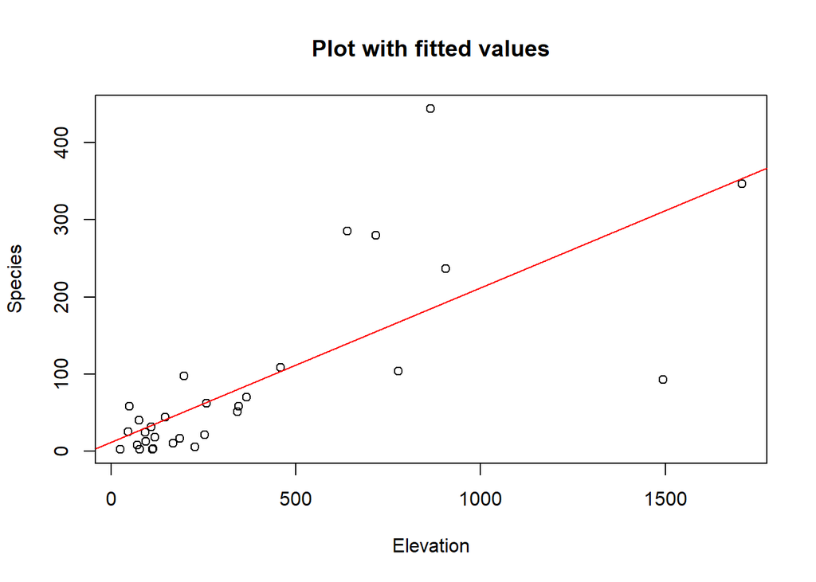

```r
plot(Species~Elevation , data = gala,
     main = "Plot with fitted values")
abline(fit, col = "Red")
```

If we are dealing with a multiple linear regression model with multiple predictor variables, we could stack all the observations and obtain the following matrix representation:

$$\begin{bmatrix}
y_1\\
\vdots\\
y_n
\end{bmatrix}
=\begin{bmatrix}
1 & x_{11} & \dots & x_{1p}\\
\vdots & \vdots & \ddots & \vdots\\
1 & x_{n1} & \dots & x_{np}
\end{bmatrix}\begin{bmatrix}
\beta_1\\
\vdots\\
\beta_p
\end{bmatrix} + \begin{bmatrix}
\epsilon_1\\
\vdots\\
\epsilon_n
\end{bmatrix}$$

$y\sim N_n(X\beta,\sigma^2I_n)$ and $\hat{\sigma}^2=\frac{\hat{\epsilon}^T\hat{\epsilon}}{n-p^*}=\frac{SSR}{n-p^*}$ for X being an $n\;x\;p^*$ matrix.

Our estimate for $\hat{\sigma}^2=\frac{SSR}{n-p^*}$

We can easily find that $E[\hat{\beta}]=\beta$ and $Var(\hat{\beta})=(X^tX)^{-1}\sigma^2$ using the fact that $\hat{\beta}=(X^TX)^{-1}X^Ty$

```r
X <- cbind(rep(1,times=length(gala$Area)), gala$Area, gala$Elevation, gala$Scruz, gala$Adjacent)
colnames(X) <- c("Intecept", "Area", "Elevation", "Scruz", "Adjacent")
Beta.hat<- solve(crossprod(X))%*%(t(X)%*%y)
t(Beta.hat)
```

```
##      Intecept        Area Elevation      Scruz    Adjacent
## [1,] 7.075377 -0.02397793 0.3195734 -0.2393552 -0.07484842
```

```r
fit1 <- lm(Species ~ Area + Elevation + Scruz + Adjacent, data=gala)
sigma.hat <- sqrt(sum(fit1$residuals^2)/(fit1$df.residual))
sigma.hat
```

```
## [1] 59.74333
```

```r
XtX.inverse <- solve(crossprod(X))
XtX.inverse
```

```
##                Intecept          Area     Elevation         Scruz      Adjacent
## Intecept   9.849524e-02  3.879513e-05 -1.589754e-04 -4.059337e-04  2.421334e-05
## Area       3.879513e-05  1.296222e-07 -2.439943e-07  1.163061e-07  4.003452e-08
## Elevation -1.589754e-04 -2.439943e-07  7.323822e-07 -1.457015e-07 -1.471043e-07
## Scruz     -4.059337e-04  1.163061e-07 -1.457015e-07  7.594187e-06 -1.368476e-08
## Adjacent   2.421334e-05  4.003452e-08 -1.471043e-07 -1.368476e-08  7.747375e-08
```

```r
Beta.hat.SE <- sigma.hat*sqrt(diag(XtX.inverse))
Beta.hat.SE
```

```
##    Intecept        Area   Elevation       Scruz    Adjacent
## 18.74981844  0.02150944  0.05112795  0.16463800  0.01662902
```

We also know that $\hat{\epsilon}=M\epsilon$, so $\frac{\hat{\epsilon}^T\hat{\epsilon}}{\sigma^2} \sim X^2(n-p^*)$

Our new $R^2$ for the MLR becomes $R^2=1-\frac{SSR}{SST}=1-\frac{y^TMy}{y^TM_1y}$ with $M_1=(I-1(1^T1)^{-1}1^T)$

We can run hypothesis tests to determine if one model is better than another given two models $M_1$ and $M_2$ with $M_2$ having more coefficients than $M_1$. To test this we want to determine how similar the SSR is for each model, we would then pick the model with the smallest SSR if there is a significant difference. With $H_0:SSR_{M_1}=SSR_{M_2}$ and $H_1:SSR_{M_1}\gt SSR_{M_2}$

We can calculate our F-statistic $F=\frac{(SSR_{M_1}-SSR_{M_2})/(df_{M_1}-df_{M_2})}{SSR_{M_2}/df_{M_2}} \sim F(df_{M_1}-df_{M_2},df_{M_2})$.

Given a significance level $\alpha$, we reject the null hypothesis if $F\gt F(1-\alpha;df_{M_1}-df_{M_2}, df_{M_2})$ or if $p-value\lt \alpha$

```r
fullmodel<- lm( Species ~ Area+Elevation+ Scruz+ Adjacent, data=gala)
nullmodel <- lm(Species~1, data=gala)
anova1<-anova(nullmodel, fullmodel)
anova1
```

```
## Analysis of Variance Table
##
## Model 1: Species ~ 1
## Model 2: Species ~ Area + Elevation + Scruz + Adjacent
##   Res.Df    RSS Df Sum of Sq      F   Pr(>F)
## 1     29 381081
## 2     25  89232  4    291850 20.442 1.39e-07 ***
## ---
## Signif. codes:  0 '***' 0.001 '**' 0.01 '*' 0.05 '.' 0.1 ' ' 1
```

```r
pval<- 1-pf(anova1$F[2],4,25)
pval
```

```
## [1] 1.389845e-07
```

$SSR_{M_1}=y^T(I-H_1)y$ with $df=n-p+1$ $SSR_{M_F}=y^T(I-H_F)y$ with $df=n-p-1$ $SSR_{M_1}-SSR_{M_F}=y^T(H_F-H_1)y$ with $df=2$

```r
fullmodel<- lm( Species ~ Area+Elevation+ Scruz+ Adjacent, data=gala)
Model1 <- lm(Species~Elevation+ Adjacent, data=gala)
anova2<-anova(Model1, fullmodel)
anova2
```

```
## Analysis of Variance Table
##
## Model 1: Species ~ Elevation + Adjacent
## Model 2: Species ~ Area + Elevation + Scruz + Adjacent
##   Res.Df    RSS Df Sum of Sq      F Pr(>F)
## 1     27 100003
## 2     25  89232  2     10771 1.5089 0.2406
```

```r
pval<- 1-pf(anova2$F[2],2,25)
pval
```

```
## [1] 0.2406149
```

```r
fit1 <- lm(Species ~ Area + Elevation + Nearest + Scruz + Adjacent, data=gala)
CIs <- cbind(summary(fit1)$coefficients[, 1]-qt(0.975, fit$df.residual)*summary(fit1)$coefficients[, 2],summary(fit1)$coefficients[, 1]+qt(0.975, fit$df.residual)*summary(fit1)$coefficients[, 2])
CIs
```

```
##                     [,1]        [,2]
## (Intercept) -32.16737491 46.30381633
## Area         -0.06986844  0.02199177
## Elevation     0.20954149  0.42938803
## Nearest      -2.15015565  2.16844357
## Scruz        -0.68175573  0.20070727
## Adjacent     -0.11106202 -0.03854764
```

```r
confint(fit1)
```

```
##                   2.5 %      97.5 %
## (Intercept) -32.4641006 46.60054205
## Area         -0.0702158  0.02233912
## Elevation     0.2087102  0.43021935
## Nearest      -2.1664857  2.18477363
## Scruz        -0.6850926  0.20404416
## Adjacent     -0.1113362 -0.03827344
```

When making CIs for predictions, there are typically two types of predictions being made in regression, prediction of response mean for a subject with characteristics $x_0$, and prediction of a future response of a new observation with characteristics $x_0$. A CI for the response mean is: $\hat{y_0}\pm t_{(t-\alpha/2;n-p^*)}\hat{\sigma}\sqrt{x_0^T(X^TX)^{-1}x_0}$. We can use either method below, the first calculates each value using the math, while the other method uses a built in function.

```r
x0 <- data.frame(Area=20.6, Elevation= 46, Nearest=1.9, Scruz=8.0, Adjacent=0.78)
x0.vector <- cbind(c(1, 20.6,46,1.9,8.0,0.78))
rownames(x0.vector) <- c("(Intercept)", "Area", "Elevation", "Nearest", "Scruz", "Adjacent")
pred.y0 <- t(x0.vector)%*%fit1$coefficients
pred.y0
```

```
##         [,1]
## [1,] 19.3053
```

```r
X <- cbind(rep(1,times=length(gala$Area)), gala$Area, gala$Elevation, gala$Nearest, gala$Scruz, gala$Adjacent)
se2.betas<- t(x0.vector)%*%(solve(t(X)%*%X))%*%x0.vector
sigma<- sigma(fit1)
predmean.CI<- c(pred.y0 - sigma*qt(0.975,fit1$df.residual)*sqrt(se2.betas),
pred.y0 + sigma* qt(0.975,fit1$df.residual)*sqrt(se2.betas))
predmean.CI
```

```
## [1] -16.42255  55.03315
```

```r
predict(fit1, newdata= x0, interval="confidence")
```

```
##       fit       lwr      upr
## 1 19.3053 -16.42255 55.03315
```

A CI for a single future observation is: $\hat{y_0}\pm t_{(1-\alpha/2;n-p^*)}\hat{\sigma}\sqrt{1+x_0^T(X^TX)^{-1}x_0}$. We can once again use either method below.

```r
pred.CI<- c(pred.y0 - sigma*qt(0.975,fit1$df.residual)*sqrt(1+se2.betas),
pred.y0 + sigma* qt(0.975,fit1$df.residual)*sqrt(1+se2.betas))
pred.CI
```

```
## [1] -111.5146  150.1252
```

```r
predict(fit1, newdata=x0, interval="prediction")
```

```
##       fit       lwr      upr
## 1 19.3053 -111.5146 150.1252
```

If we wanted to check Homoscedasticity, or see if the data has constant variance, of our model, i.e. plotting the Residuals (vertical axis) vs the fitted values $\hat{y}$ (horizontal axis) we would do the following:

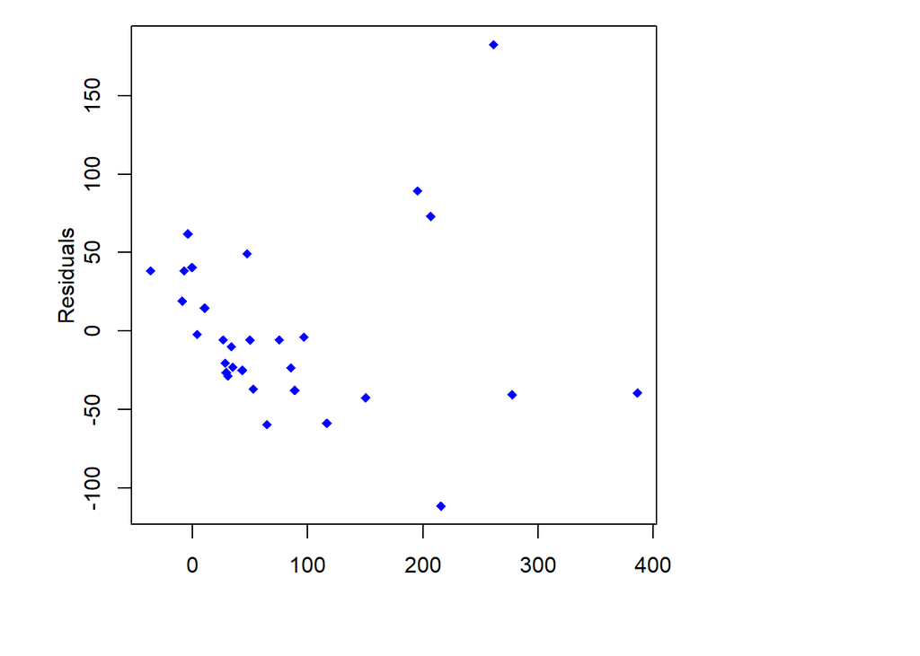

```r
par(mar = c(5, 5, 1, 10))
plot(fitted(fit1), residuals(fit1), xlab="",ylab="", col="blue", pch=18);mtext(side=2, text="Residuals", line=2)
```

We could also check the normality of our model:

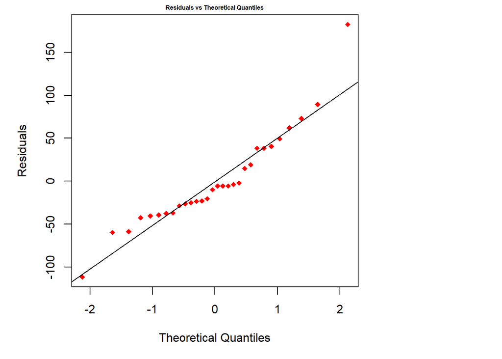

```r
par(mar = c(5, 5, 1, 10))
qqnorm(residuals(fit1), ylab="Residuals",main="", pch=18, col="red")
qqline(residuals(fit1))
title("Residuals vs Theoretical Quantiles", cex.main=0.5)
```

Or we could run a Shapiro test with null hypothesis $H_0:$Residuals Are Normal:

```r
shapiro.test(residuals(fit1))
```

```
##
##  Shapiro-Wilk normality test
##
## data:  residuals(fit1)
## W = 0.91351, p-value = 0.01826
```

To check the correlation between our errors, we could plot time or space vs our residuals, and we would expect a random scatter of points above and below $\hat{\epsilon}=0$:

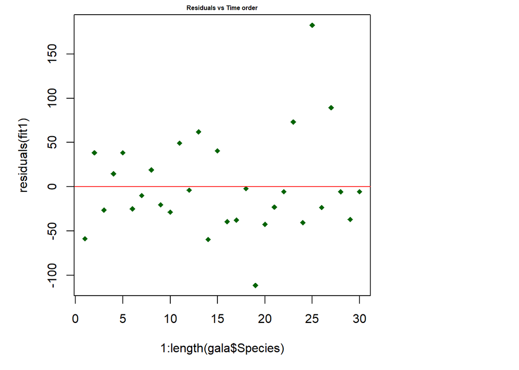

```r
par(mar = c(5, 5, 1, 10))
plot(1:length(gala$Species), residuals(fit1), col="darkgreen", pch=18)
abline(h=0. ,col="red")
title("Residuals vs Time order", cex.main=0.5)
```

We could also run a Durvin-Watson test:

```r
dwtest(fit1)
```

```
##
##  Durbin-Watson test
##
## data:  fit1
## DW = 2.4759, p-value = 0.9017
## alternative hypothesis: true autocorrelation is greater than 0
```

If we wanted to calculate the leverage score for every value, or the weighted distance between $X_i$ and the average point of the $X_i 's$. We also know that $\sum_{i=1}^nh_i=p^*=p+1$

```r
data(savings)
lmod<- lm(sr ~ pop15 + pop75+ dpi+ ddpi, savings)
X<- model.matrix(lmod)
hatv <- diag(X%*%(solve(t(X)%*%X))%*%t(X))
hatv2<- hatvalues(lmod)
all.equal(hatv, hatv2)
```

```
## [1] TRUE
```

```r
sum(hatv2)
```

```
## [1] 5
```

We can plot these leverage scores to determine which ones might have a very large influence on our model. Anything larger than $2\bar{h}$ is considered a large leverage score.

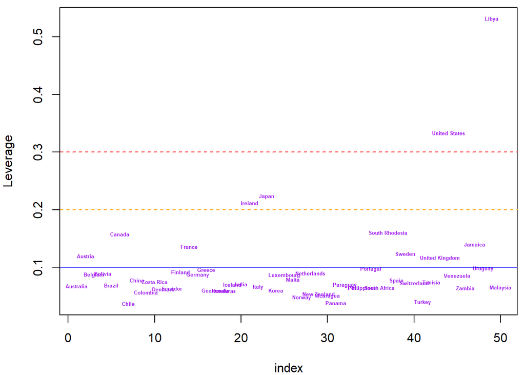

```r
data.lev<- data.frame(index=seq(length(hatv)),
Leverage=hatv, namesC=rownames(savings))
par(mar = c(4, 4, 0.5, 0.5))
plot(Leverage ~ index, data=data.lev, col="white", pch=NULL)
text(Leverage ~ index, labels=namesC, data=data.lev, cex=0.4, font=2, col="purple")
abline(h = sum(hatv2)/dim(data.lev)[1], col="blue")
abline(h = 2*sum(hatv2)/dim(data.lev)[1], col="orange", lty=2)
abline(h = 3*sum(hatv2)/dim(data.lev)[1], col="red", lty=2)
```

If we wanted to determine outliers in our data, we can calculate standardized residuals: $r_i=\frac{y_i-\bar{y}_i}{\hat{\sigma}\sqrt{1-h_i}}$. Any $|r_i|\geq 3$ is an outlier.

```r
r1<- residuals(lmod)/(sigma(lmod)*sqrt(1-hatv))
r2<- rstandard(lmod)
all.equal(r1,r2)
```

```
## [1] TRUE
```

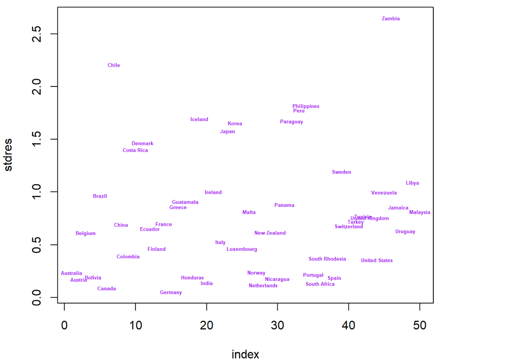

```r
data.sres<- data.frame(index=seq(length(r2)),
stdres=abs(r2), namesC=rownames(savings))
par(mar = c(4, 4, 0.5, 5))
plot(stdres ~ index, data=data.sres, col="white", pch=NULL)
text(stdres ~ index, labels=namesC, data=data.sres, cex=0.4, font=2, col="purple")
abline(h=3, col="red", lty=2)
```

We can calculate cook’s distance to determine influential observations, or points that when removed would cause significant change in the model. $D_i=\frac{(\hat{y}-\hat{y}_{(i)})^T(\hat{y}-\hat{y}_{(i)})}{p^*\hat{\sigma}^2}=\frac{1}{p^*}r_i^2\frac{h_i}{1-h_i}$

```r
cook1<- (r1^2/dim(X)[2])* hatv/(1-hatv)
cook2<- cooks.distance(lmod)
all.equal(cook1,cook2)
```

```
## [1] TRUE
```

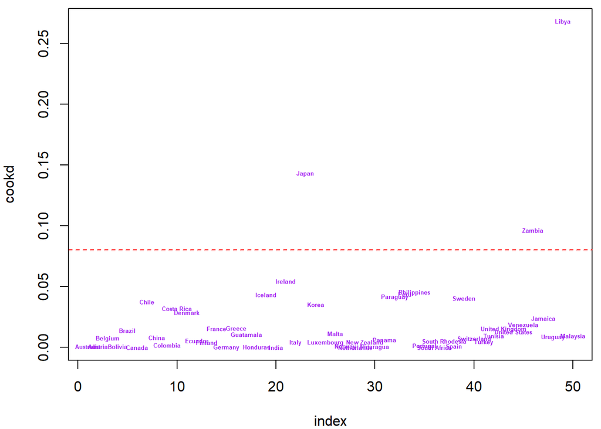

```r
data.cook<- data.frame(index=seq(length(r2)),
cookd=abs(cook2), namesC=rownames(savings))
par(mar = c(4, 4, 0.5, 0.5))
plot(cookd ~ index, data=data.cook, col="white", pch=NULL)
text(cookd ~ index, labels=namesC, data=data.cook, cex=0.4, font=2, col="purple")
abline(h=4/dim(X)[1], col="red", lty=2)
```

If we wanted to transform our response, we could determine the most suitable transformation using a box-cox transformation. We could make a CI for lambda with the following. If it contains 1, no transformation is necessary.

[figure not shown]

```r
mod<- lm(sr ~ pop15 + pop75+ dpi+ ddpi, savings)
par(mfrow=c(1,2), mar = c(2, 2, 0.8, 0.5))
boxcox(lmod, plotit =TRUE)
boxcox(lmod, plotit =TRUE, lambda=seq(0.5, 1.5, by=0.5))
```

We could also add polynomial terms to generalize the linear structure:

$y=\beta_0+\beta_1x+\beta_2x^2+...+\beta_dx^d+\epsilon$

The two common ways to pick the value for d is to keep adding terms until it is not statistically significant, or to start with a large d, and remove non-statistically significant terms:

```r
summary(m1<-lm(sr~ddpi, savings))$coefficients
```

```
##             Estimate Std. Error  t value     Pr(>|t|)
## (Intercept) 7.883021  1.0110011 7.797243 4.464697e-10
## ddpi        0.475830  0.2146166 2.217117 3.138509e-02
```

```r
summary(m2<-lm(sr~ddpi + I(ddpi^2), savings))$coefficients
```

```
##                Estimate Std. Error   t value     Pr(>|t|)
## (Intercept)  5.13038069 1.43471517  3.575888 0.0008211413
## ddpi         1.75751897 0.53772368  3.268443 0.0020258542
## I(ddpi^2)   -0.09298521 0.03612318 -2.574115 0.0132617330
```

```r
summary(m3<-lm(sr~ddpi + I(ddpi^2)+ I(ddpi^3), savings))$coefficients
```

```
##                  Estimate Std. Error      t value   Pr(>|t|)
## (Intercept)  5.145360e+00 2.19860644  2.340282237 0.02366212
## ddpi         1.746017e+00 1.38045499  1.264812459 0.21230898
## I(ddpi^2)   -9.096724e-02 0.22559835 -0.403226554 0.68864973
## I(ddpi^3)   -8.496955e-05 0.00937393 -0.009064453 0.99280691
```

When we have $p>1$, we can use the following formula:

$y=\beta_0+\sum_{i=1}\beta_jx_j+\sum_{i\leq j}a_{ij}x_ix_j+\epsilon$

```r
par(mar = c(3, 2, 1.5, 0.5))
modelint<- lm(sr ~ pop15*ddpi + I(ddpi^2) + I(pop15^2), savings) #By using pop15*ddpi we add degree 1 terms
summary(modelint)$coefficients
```

```
##                Estimate  Std. Error    t value   Pr(>|t|)
## (Intercept) 14.32272231 12.99818146  1.1019020 0.27649541
## pop15       -0.44577097  0.75595872 -0.5896763 0.55842372
## ddpi         2.58494246  1.07001582  2.4157984 0.01991977
## I(ddpi^2)   -0.03567898  0.03972424 -0.8981664 0.37398561
## I(pop15^2)   0.00571870  0.01067209  0.5358557 0.59475693
## pop15:ddpi  -0.04166178  0.03042031 -1.3695381 0.17778077
```

```r
modelint2<- lm(sr ~ pop15*ddpi, savings) #Excluding degree 2 terms
summary(modelint2)$coefficients
```

```
##                Estimate Std. Error    t value   Pr(>|t|)
## (Intercept)  7.59867182 4.49133342  1.6918521 0.09743877
## pop15       -0.01520380 0.11373407 -0.1336785 0.89423995
## ddpi         2.59309111 1.05992616  2.4464828 0.01830752
## pop15:ddpi  -0.05464617 0.02651832 -2.0606951 0.04501275
```

To fit a generalized additive model

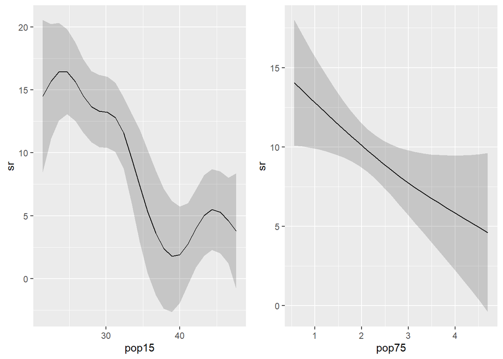

```r
par(mar = c(3, 2, 0.5, 0.5))
gamod<- gam(sr ~ s(pop15) + s(pop75) + s(dpi) + s(ddpi), data=savings)
p1<-plot_smooths(gamod, pop15); p2<-plot_smooths(gamod, pop75)
grid.arrange(p1, p2, ncol = 2, nrow = 1)
```

We could create a generalized least squares estimate:

```r
data(divusa)
gmod <- gls(divorce ~year, correlation=corAR1(form=~year),data=divusa)
summary(gmod)
```

```
## Generalized least squares fit by REML
##   Model: divorce ~ year
##   Data: divusa
##        AIC      BIC    logLik
##   216.2057 225.4756 -104.1028
##
## Correlation Structure: AR(1)
##  Formula: ~year
##  Parameter estimate(s):
##       Phi
## 0.9955474
##
## Coefficients:
##                  Value Std.Error   t-value p-value
## (Intercept) -283.78012 195.07262 -1.454741  0.1499
## year           0.15192   0.09952  1.526571  0.1311
##
##  Correlation:
##      (Intr)
## year -0.999
##
## Standardized residuals:
##        Min         Q1        Med         Q3        Max
## -0.4900705 -0.2675280 -0.1277208  0.2248171  0.6060676
##
## Residual standard error: 9.972029
## Degrees of freedom: 77 total; 75 residual
```

To study categorical data, we will use the high-school data set:

```r
data(hsb)
head(hsb,10)
```

```
##     id gender         race    ses schtyp     prog read write math science socst
## 1   70   male        white    low public  general   57    52   41      47    57
## 2  121 female        white middle public vocation   68    59   53      63    61
## 3   86   male        white   high public  general   44    33   54      58    31
## 4  141   male        white   high public vocation   63    44   47      53    56
## 5  172   male        white middle public academic   47    52   57      53    61
## 6  113   male        white middle public academic   44    52   51      63    61
## 7   50   male african-amer middle public  general   50    59   42      53    61
## 8   11   male     hispanic middle public academic   34    46   45      39    36
## 9   84   male        white middle public  general   63    57   54      58    51
## 10  48   male african-amer middle public academic   57    55   52      50    51
```

```r
summary(hsb[,-1])
```

```
##     gender              race         ses         schtyp          prog
##  female:109   african-amer: 20   high  :58   private: 32   academic:105
##  male  : 91   asian       : 11   low   :47   public :168   general : 45
##               hispanic    : 24   middle:95                 vocation: 50
##               white       :145
##
##
##       read           write            math          science
##  Min.   :28.00   Min.   :31.00   Min.   :33.00   Min.   :26.00
##  1st Qu.:44.00   1st Qu.:45.75   1st Qu.:45.00   1st Qu.:44.00
##  Median :50.00   Median :54.00   Median :52.00   Median :53.00
##  Mean   :52.23   Mean   :52.77   Mean   :52.65   Mean   :51.85
##  3rd Qu.:60.00   3rd Qu.:60.00   3rd Qu.:59.00   3rd Qu.:58.00
##  Max.   :76.00   Max.   :67.00   Max.   :75.00   Max.   :74.00
##      socst
##  Min.   :26.00
##  1st Qu.:46.00
##  Median :52.00
##  Mean   :52.41
##  3rd Qu.:61.00
##  Max.   :71.00
```

To include two-level factors in our model, we must use dummy variables, so if we wanted to study the response of Science Score as a function of School Type (Public/Private), we define the dummy variable with respect to level Public:

$$z_i=\left\{
\begin{array}{ll}
1 & if \;ith \in Public\\
0 & if \;ith \not\in Public\\
\end{array}
\right.$$

Thus, the linear model is: $y=\beta_0+\beta_{public}z_i+\epsilon_i$ with $\beta_{public}=\bar{y}_{public}-\bar{y}_{private}$

Both methods below produce the same result:

```r
lmod <- lm(science~schtyp, hsb)
summary(lmod)$coefficients
```

```
##               Estimate Std. Error    t value     Pr(>|t|)
## (Intercept)  53.312500   1.750993 30.4470164 1.257740e-76
## schtyppublic -1.741071   1.910490 -0.9113221 3.632338e-01
```

```r
lmod2 <- lm(science~as.factor(schtyp), hsb)
summary(lmod2)$coefficients
```

```
##                          Estimate Std. Error    t value     Pr(>|t|)
## (Intercept)             53.312500   1.750993 30.4470164 1.257740e-76
## as.factor(schtyp)public -1.741071   1.910490 -0.9113221 3.632338e-01
```

If we wanted the dummy variable to be with respect to the level Private and wanted to calculate the $z_i$ values:

```r
private<- ifelse(hsb$schtyp=="private", 1, 0)
lmod3 <- lm(science~private, hsb) ;summary(lmod3)$coefficients
```

```
##              Estimate Std. Error    t value      Pr(>|t|)
## (Intercept) 51.571429  0.7641958 67.4845733 1.317579e-138
## private      1.741071  1.9104895  0.9113221  3.632338e-01
```

If we wanted to include a quantitative variable x, we have two options. Separate regression lines for each level with the same or different slope.

Same slope:

```r
lmod4 <- lm(science~math+schtyp, hsb)
summary(lmod4)$coefficients
```

```
##                 Estimate Std. Error     t value     Pr(>|t|)
## (Intercept)  16.83230818 3.49241733  4.81967262 2.867077e-06
## math          0.66630487 0.05871397 11.34831838 2.714636e-23
## schtyppublic -0.07134314 1.49665267 -0.04766847 9.620288e-01
```

Different slope:

```r
lmod5 <- lm(science~math+schtyp + math:schtyp , hsb)
summary(lmod5)$coefficients
```

```
##                      Estimate Std. Error    t value     Pr(>|t|)
## (Intercept)       21.00194195  8.6726120  2.4216397 0.0163611963
## math               0.59014718  0.1564221  3.7727875 0.0002137695
## schtyppublic      -4.89629406  9.3042936 -0.5262403 0.5993162301
## math:schtyppublic  0.08870108  0.1688129  0.5254403 0.5998710777
```

When attempting to find the best model possible, we look to use Occam’s Razor Principle and find a model that has a good fit with not much complexity. We consider two classes of schemes to drive variable selection:

1. Model Comparison
2. Regularization

If we are dealing with models that are nested, one that is a subet of the other, we can simply use the F-test with F-statistic:

$F=\frac{(SSR_{M_0}-SSR_M)/(p-q)}{SSR_{M}/(n-p)}\sim F_{(p-q,n-p)}$

If $F>F_{(p-q,n-p)}$ we reject $H_0$.

If we are dealing with non-nested models, we have a few criteria for comparing them. The first include the AIC and BIC(k=number of predictors):

$AIC=n*log(SSR/n)+2k$

$BIC=n*log(SSR/n)+k*log(n)$

Small values of AIC and BIC are preferred.

To see this, we will use the state data set and the regsubsets function to search through all possible combinations of predictors and find the variables for each model size k that produce the minimum SSR. By looking at rs$which, we can see which variables are used in each model size.

```r
data(state)
statedata <- data.frame(state.x77, row.names=state.abb)
models <- regsubsets(Life.Exp ~ ., statedata)
rs <- summary(models)
rs$which
```

```
##   (Intercept) Population Income Illiteracy Murder HS.Grad Frost  Area
## 1        TRUE      FALSE  FALSE      FALSE   TRUE   FALSE FALSE FALSE
## 2        TRUE      FALSE  FALSE      FALSE   TRUE    TRUE FALSE FALSE
## 3        TRUE      FALSE  FALSE      FALSE   TRUE    TRUE  TRUE FALSE
## 4        TRUE       TRUE  FALSE      FALSE   TRUE    TRUE  TRUE FALSE
## 5        TRUE       TRUE   TRUE      FALSE   TRUE    TRUE  TRUE FALSE
## 6        TRUE       TRUE   TRUE       TRUE   TRUE    TRUE  TRUE FALSE
## 7        TRUE       TRUE   TRUE       TRUE   TRUE    TRUE  TRUE  TRUE
```

To calculate both AIC and BIC we can do the following:

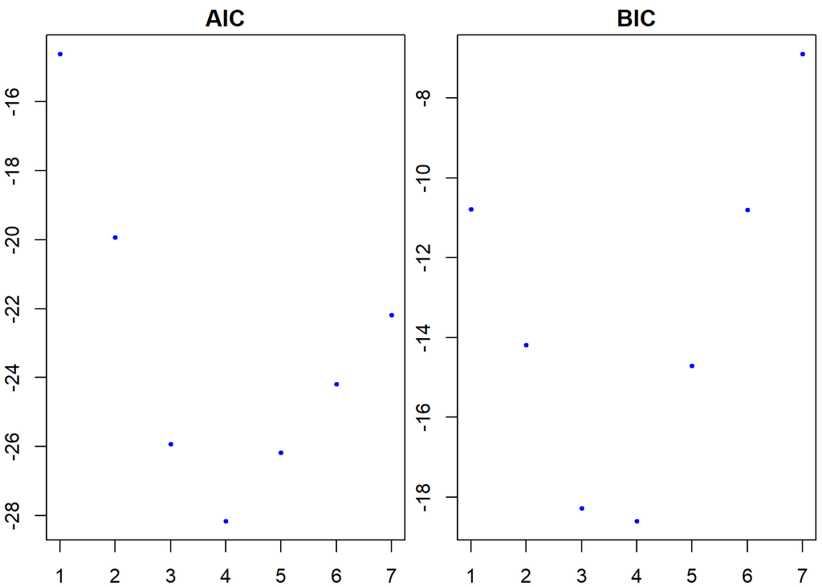

```r
n<- dim(statedata)[1]
AIC<- n*log(rs$rss/n) + 2*seq(2,8,1)
BIC<- n*log(rs$rss/n) + log(n)*seq(2,8,1)
par(mar = c(2, 2, 1.5, 0.25), mfrow=c(1,2))
plot(AIC~I(1:7), main="AIC", xlab="# Predictors", pch=20, col="blue", cex=0.7)
plot(BIC~I(1:7), main="BIC", xlab="# Predictors", pch=20, col="blue", cex=0.7)
```

We could also use the Adjusted $R^2$ criterion $(R^2_A)$:

$R^2_A=1-\frac{SSR/(n-k)}{SST/(n-1)}$

This gives a value between 0 and 1, with a larger value being better.

Our final criterion we can check is Mallow’s $C_p$ Statistic:

$C_k=SSR_k/\sigma^2_p+2k-n$

We desire models with small k and with $C_k\leq k$

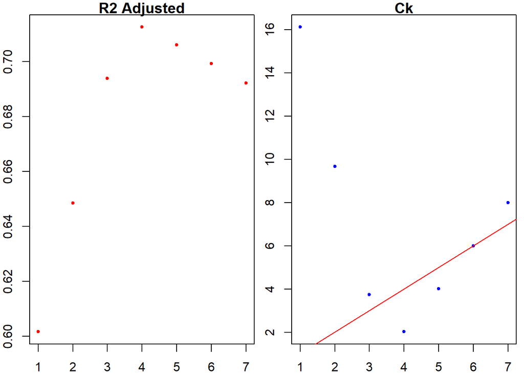

```r
par(mar = c(2, 2, 1, 0.5), mfrow=c(1,2))
r2Ad<- rs$adjr2
Ck<- rs$cp
plot(r2Ad~I(1:7), main="R2 Adjusted", xlab="# Predictors", pch=20, col="red", cex=0.8)
plot(Ck~I(1:7), main="Ck", xlab="# Predictors", pch=20, col="blue", cex=0.8)
abline(0,1, col="red")
```

For p predictors, there are $2^p$ possible models.

There are two different step-wise procedures, forward and backward, for eliminating variables to get the best possible model:

```r
lmod <- lm(Life.Exp~., statedata)
stats::step(lmod)
```

```
## Start:  AIC=-22.18
## Life.Exp ~ Population + Income + Illiteracy + Murder + HS.Grad +
##     Frost + Area
##
##              Df Sum of Sq    RSS     AIC
## - Area        1    0.0011 23.298 -24.182
## - Income      1    0.0044 23.302 -24.175
## - Illiteracy  1    0.0047 23.302 -24.174
## <none>                    23.297 -22.185
## - Population  1    1.7472 25.044 -20.569
## - Frost       1    1.8466 25.144 -20.371
## - HS.Grad     1    2.4413 25.738 -19.202
## - Murder      1   23.1411 46.438  10.305
##
## Step:  AIC=-24.18
## Life.Exp ~ Population + Income + Illiteracy + Murder + HS.Grad +
##     Frost
##
##              Df Sum of Sq    RSS     AIC
## - Illiteracy  1    0.0038 23.302 -26.174
## - Income      1    0.0059 23.304 -26.170
## <none>                    23.298 -24.182
## - Population  1    1.7599 25.058 -22.541
## - Frost       1    2.0488 25.347 -21.968
## - HS.Grad     1    2.9804 26.279 -20.163
## - Murder      1   26.2721 49.570  11.569
##
## Step:  AIC=-26.17
## Life.Exp ~ Population + Income + Murder + HS.Grad + Frost
##
##              Df Sum of Sq    RSS     AIC
## - Income      1     0.006 23.308 -28.161
## <none>                    23.302 -26.174
## - Population  1     1.887 25.189 -24.280
## - Frost       1     3.037 26.339 -22.048
## - HS.Grad     1     3.495 26.797 -21.187
## - Murder      1    34.739 58.041  17.456
##
## Step:  AIC=-28.16
## Life.Exp ~ Population + Murder + HS.Grad + Frost
##
##              Df Sum of Sq    RSS     AIC
## <none>                    23.308 -28.161
## - Population  1     2.064 25.372 -25.920
## - Frost       1     3.122 26.430 -23.877
## - HS.Grad     1     5.112 28.420 -20.246
## - Murder      1    34.816 58.124  15.528
```

```
##
## Call:
## lm(formula = Life.Exp ~ Population + Murder + HS.Grad + Frost,
##     data = statedata)
##
## Coefficients:
## (Intercept)   Population       Murder      HS.Grad        Frost
##   7.103e+01    5.014e-05   -3.001e-01    4.658e-02   -5.943e-03
```

One way to reduce extra terms in our model is Ridge Regression. This is useful in the presence of collinearity and if we have many p values that have some effect on the response. After scaling our response and predictors, we can perform ridge regression and choose $\beta$ that minimizes:

$SSR+\lambda\sum_{j=1}^p\beta^2_j=(y-X\beta)^T(y-X\beta)+\lambda||\beta||^2_2$

The solution for the estimates of $\beta$ can be written as:

$\hat{\beta}=(X^TX+\lambda I)^{-1}X^Ty$

```r
par(mar = c(2, 2, 0.5, 0.5))
seatpos
```

```
##    Age Weight HtShoes    Ht Seated  Arm Thigh  Leg hipcenter
## 1   46    180   187.2 184.9   95.2 36.1  45.3 41.3  -206.300
## 2   31    175   167.5 165.5   83.8 32.9  36.5 35.9  -178.210
## 3   23    100   153.6 152.2   82.9 26.0  36.6 31.0   -71.673
## 4   19    185   190.3 187.4   97.3 37.4  44.1 41.0  -257.720
## 5   23    159   178.0 174.1   93.9 29.5  40.1 36.9  -173.230
## 6   47    170   178.7 177.0   92.4 36.0  43.2 37.4  -185.150
## 7   30    137   165.7 164.6   87.7 32.5  35.6 36.2  -164.750
## 8   28    192   185.3 182.7   96.9 35.8  39.9 43.1  -270.920
## 9   23    150   167.6 165.0   91.4 29.4  35.5 33.4  -151.780
## 10  29    120   161.2 158.7   85.2 26.6  31.0 32.8  -113.880
## 11  47    143   171.9 169.1   87.8 32.9  39.2 36.9  -196.150
## 12  41    107   155.7 152.5   82.9 29.6  32.7 31.1  -125.550
## 13  51    227   179.8 177.2   91.7 31.1  41.4 40.2  -203.610
## 14  30    147   164.9 162.7   88.0 27.7  33.6 33.8  -163.220
```

[output cut: 24 more lines]

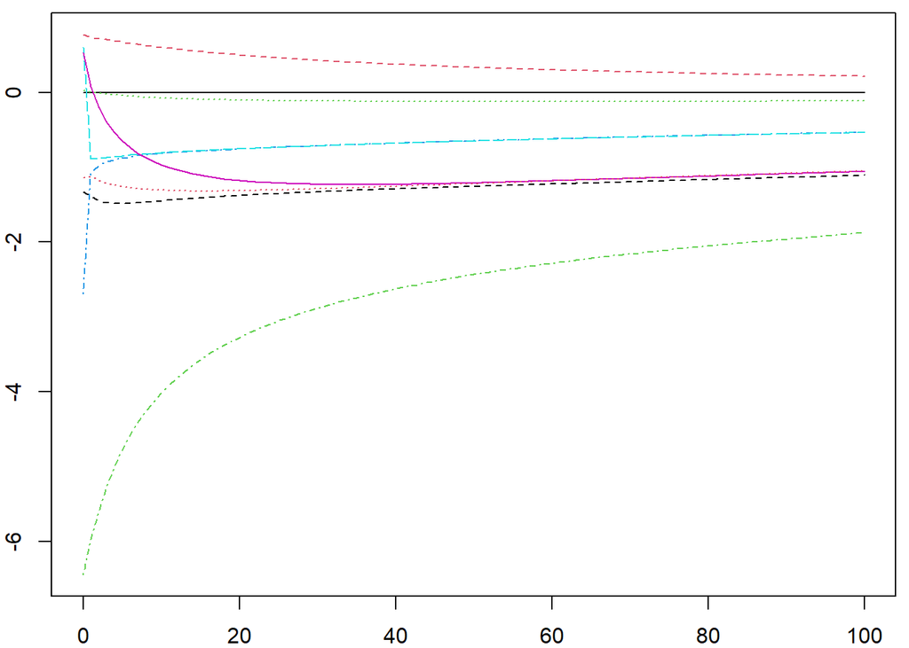

```r
seatpos<- scale((seatpos), center = TRUE, scale = FALSE)
seatpos<- as.data.frame(seatpos)
rgmod<- lm.ridge(hipcenter~., seatpos, lambda = seq(0,100, len=101))
matplot(rgmod$lambda, coef(rgmod), type="l", xlab = "lambda", ylab = "Beta hat", cex=0.8)
```

We try to find the model with the lowest generalized cross-validation

```r
a<-which.min(rgmod$GCV)
a
```

```
##  22
##  23
```

```r
coef(rgmod)[a,]
```

```
##                         Age        Weight       HtShoes            Ht
## -4.474092e-16  4.856720e-01 -1.040068e-01 -7.455662e-01 -7.437565e-01
##        Seated           Arm         Thigh           Leg
## -1.193029e+00 -1.362920e+00 -1.307818e+00 -3.177078e+00
```

We could also perform Lasso Regression to shrink the terms. This form of regression can shrink some $\beta$ terms to exactly zero, allowing us to remove the corresponding predictor. We choose $\beta$ that minimizes:

$SSR+\lambda \sum_{i=1}^p|\beta_j|=(y-X\beta)^T(y-x\beta)+\lambda||\beta||_1$

```r
data(state)
statedata<- data.frame(state.x77, row.names =state.abb)
y <- statedata$Life
x <- scale(data.matrix(statedata[,-4]))
cv_model <- cv.glmnet(x, y, alpha = 1)
best_lambda <- cv_model$lambda.min
best_lambda
```

```
## [1] 0.04816425
```

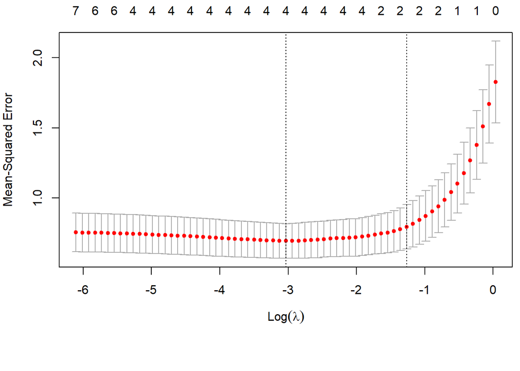

```r
par(mar = c(7, 4, 2.2, 0.5));plot(cv_model, cex=0.8)
```

```r
best_model <- glmnet(x, y, alpha = 1, lambda = best_lambda)
coef(best_model)
```

```
## 8 x 1 sparse Matrix of class "dgCMatrix"
##                     s0
## (Intercept) 70.8786000
## Population   0.1696933
## Income       .
## Illiteracy   .
## Murder      -1.0068782
## HS.Grad      0.3347883
## Frost       -0.2085678
## Area         .
```